# Notes on implementing phylogenetic random effects

Author

Ben Bolker

Published

August 23, 2026

```r
if (!require("MRFtools")) {
    stop('please remotes::install_github("eric-pedersen/MRFtools")')
    ##remotes::install_github("eric-pedersen/MRFtools")
}

## data / data manipulation
library(ape)
library(dplyr)
library(tibble)  ## lst(), rownames_to_column()
## modeling
library(glmmTMB)
library(RTMB)
library(reformulas)
library(MRFtools)
library(Matrix)
## model diagnostics, etc.
library(bbmle) ## AICtab
library(ggplot2); theme_set(theme_bw())
library(cowplot)
```

```r
source("phyloslopes_utils.R")
```

This note covers two different topics:

- **implementing phylogenetic random-effect terms**: comparing computational efficiency of different methods for implementing a simple phylogenetic covariance term, i.e. a Brownian-motion evolutionary model of a single response [intercept-only random effect] on a tree.
- **combining phylogenetic terms with other dimensions of variation**: what are our options when fitting a random-slopes phylogenetic model, or a model with both phylogenetic covariance and a functional smooth (say, a thin-plate [penalized regression] spline)? This question parallels the examples in the ‘GAM mafia’ hierarchical-GAMs paper (Pedersen *et al.*, 2019); however, the hierarchical grouping variables there are unstructured iid groups, whereas I want to allow for phylogenetic structure among groups. This note is also similar to the suggestion by the example that Clark (2024) gives, although I consider more different options.

This note is inspired by a manuscript in progress with Maeve McGillycuddy *et al.* on the `propto` functionality in `glmmTMB`; it also draws on an older, incomplete project (manuscript/R package) with Mike Li ([phyloglmm](https://github.com/wzmli/phyloglmm/)).

Most of the examples below will be implemented in RTMB for flexibility and comparability, although I’ll also compare some results with `glmmTMB` equivalents. I’m also going to stick to optimization/MLE fits for now, not considering Bayesian/sampling approaches. (The `phyloglmm` repo does a wider comparison across packages.)

## Implementing simple phylogenetic terms

For the examples below, I will use both the phylogenetic running-speed data set from Garland and Janis (1993) (as provided by the `ade4` R package) [$\approx$ 50 species], used in McGillycuddy *et al.*’s ms., and the fish phylogeny as provided by the `fishtree` R package) [$\approx$ 11K species] (Rabosky *et al.*, 2018).

### Cost of computing $\boldsymbol \Sigma$ / $\mathbf Q$

Summary of results (solely of computing $\boldsymbol \Sigma$ or $\mathbf Q$ or their sparse analogs - no consideration of their downstream efficiency - using random subsamples of the 11K tips fish phylogeny:

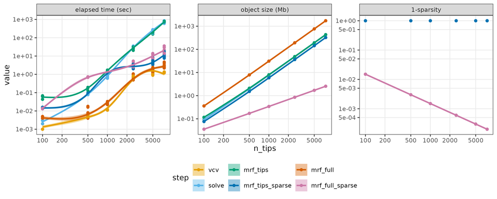

where:

- `vcv`: compute phylogenetic covariance matrix $\boldsymbol \Sigma$ from phylogeny
- `solve`: invert $\boldsymbol \Sigma$ to get $\mathbf Q$
- `mrf_tips`: compute $\mathbf Q$ based on tips only (no internal nodes) using `MRFtools::mrf_penalty.phylo`
- `mrf_tips_sparse`: convert previous object to a sparse matrix
- `mrf_full`: compute $\mathbf Q$ including internal nodes (with `mrf_penalty.phylo`)
- `mrf_full_sparse`: convert to sparse representation

**FIXME/TODO**: can `MRFtools` do a better job maintaining sparsity throughout?

### Cost of fitting intercept-only phylogeny terms

While it’s useful to know how expensive it is to compute $\boldsymbol \Sigma$ or $\mathbf Q$, the actual model-fitting step probably takes longer (because we have to evaluate expressions involving $\boldsymbol \Sigma$ or $\mathbf Q$ hundreds of times).

McGillycuddy et al. fit the model `log_rs ~ f(log_bm) + propto(0 + species | g, vcmat)` i.e., “log of running speed is linearly related to (a function of) log of body mass; phylogenetic covariance among species follows the covariance matrix `vcmat`”) to the data from Garland and Janis (1993). They first consider a (log-log) linear model for body mass, then a thin-plate spline. I’ll start with the linear model, to focus on the computational cost of the phylogenetic term. I’ll first show how to set up a series of `RTMB` models that implement different methods:

#### basic setup/glmmTMB model

```r
## FIXME: put this code elsewhere?
data("carniherbi49", package = "ade4")
chtree <- read.tree(text=carniherbi49$tre2)
chtree$tip.label <- fixup_species(chtree$tip.label)
vcmat <- vcv(chtree)  ## covariance matrix
chdat <- carniherbi49$tab2 |>
  mutate(log_bm = log(bodymass),
         log_rs = log(runningspeed),
         g = 1  ## dummy for grouping variable
         ) |>
  tibble::rownames_to_column("species") |>
  mutate(across(species, fixup_species)) |>
  mutate(across(species, \(x) factor(x, levels = rownames(vcmat))))
## check
stopifnot(identical(sort(rownames(vcmat)), sort(as.character(chdat$species))))
save(chdat, chtree, vcmat, file = "phyloslopes.rda")
```

The first model fitted by McGillycuddy *et al.*:

```r
fit_propto_glmmTMB <- glmmTMB(log_rs ~ log_bm + propto(0 + species | g, vcmat),
                              data = chdat)
```

#### RTMB analog

An RTMB analog of this model:

```r
nllfun1 <- function(params) {
  getAll(params, chdat_x)
  mu <- drop(X %*% beta + Z %*% b)
  resid <- log_rs - mu
  pen <- -dmvnorm(b, 0, Sigma = vcmat, scale = exp(logpsd), log = TRUE)
  lik <- -sum(dnorm(log_rs, mean = mu, sd = exp(logsd), log = TRUE))
  lik + pen
}
```

Setup to use this RTMB function to fit:

```r
X <- model.matrix(~ log_bm, data = chdat)
Z <- fac2sparse(chdat$species)
## for intercept-slope model
us2 <- unstructured(2)
rt <- mkReTrms(findbars(~ (1 + log_bm | species)),
               fr = chdat, calc.lambdat = FALSE)
## move data into required wrapper
chdat_x <- c(chdat, lst(X, Z, vcmat))
p0 <- list(beta = rep(0, 2), b = rep(0, nrow(vcmat)), logsd=0, logpsd = 0)
obj <- MakeADFun(nllfun1, p0, silent = TRUE, random = "b")
fit_propto_TMB <- TMBfit(obj) ## wrapper to run nlminb() and store results
## check match
stopifnot(all.equal(fixef(fit_propto_TMB), fixef(fit_propto_glmmTMB)$cond,
                    check.attributes = FALSE, tolerance = 1e-7))
```

#### RTMB with precision matrix (hand-inverted)

We can change this to a precision-based approach by changing just the penalty line, to:

```r
pen <- -dgmrf(b, 0, Q = phyloprec, scale = exp(-logpsd), log = TRUE)
```

(`dgmrf` stands for “distribution of a Gaussian Markov random field”, i.e. a multivariate Normal parameterized by its precision matrix) and inverting the covariance matrix:

```r
chdat_x <- c(chdat, lst(X, Z, phyloprec = Matrix(solve(vcmat), sparse = TRUE)))
obj <- MakeADFun(nllfun_prec, p0, silent = TRUE, random = "b")
```

#### RTMB with internal-nodes precision matrix

`MRFtools::mrf_penalty()` offers the option (with `internal_nodes = TRUE`) of generating a penalty matrix that includes all of the internal nodes. To use this, we have to be a little careful because this full matrix includes the root, and is thus rank-deficient ($\textrm{rank}(\mathbf Q) = \textrm{dim}(\mathbf Q)-1$): the classic Brownian-motion “no fixed origin” singularity, since shifting every node (including the root) by the same constant leaves all edge contrasts unchanged. We drop the root’s row/column from the precision matrix (and the corresponding column from `Z`), and change the length of `b` to match:

```r
ntip <- length(chtree$tip.label)
Q_full_raw <- mrf_penalty(chtree, "brownian", internal_nodes = TRUE)
Q_allnodes <- drop_mrf_root(chtree, Q_full_raw)
## fac2sparse() returns levels x observations (the "Zt" convention); use
## placeholder levels 1:Nnode for the (never-observed -> all-zero-column)
## internal nodes, then transpose to the usual observations x levels form
Z_full <- t(fac2sparse(factor(chdat$species,
                              levels = c(seq_len(chtree$Nnode), chtree$tip.label)),
                       drop.unused.levels = FALSE))
Z_allnodes <- Z_full[, -1]
p0_allnodes <- modifyList(p0, list(b = rep(0, chtree$Nnode + ntip - 1)))
chdat_x <- c(chdat, lst(X, Z = Z_allnodes, phyloprec = Q_allnodes))
obj_prec_allnodes <- MakeADFun(nllfun_prec, p0_allnodes, silent = TRUE, random = "b")
fit_prec_allnodes <- TMBfit(obj_prec_allnodes)
```

These results are equivalent.

#### RTMB with Z-encoding

```r
pen <- -sum(dnorm(b, 0, sd = exp(logpsd), log = TRUE))
```

Setup:

```r
pZ <- phylo_to_Z(chtree)
Z_edge <- pZ[as.character(chdat$species), ] ## reorder
p0_edge <- modifyList(p0, list(b = rep(0, nrow(chtree$edge))))
chdat_x <- c(chdat, lst(X, Z = Z_edge))
obj_edge <- MakeADFun(nllfun_edge, p0_edge, silent = TRUE, random = "b")
fit_edge <- TMBfit(obj_edge)
```

#### Timings

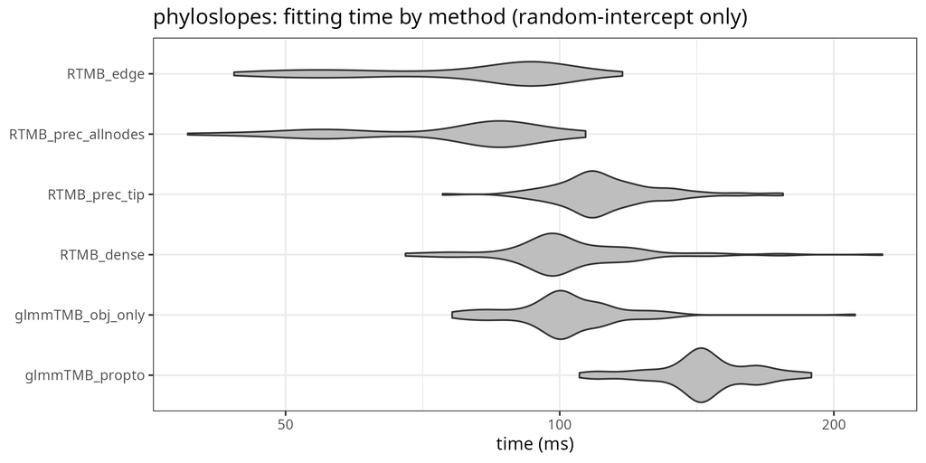

Where

- `RTMB_edge`: construction with phylogenetic structure in $\mathbf Z$
- `RTMB_prec_allnodes`: with `mrf_penalty(., internal_nodes = TRUE)`
- `RMB_prec_tip`: with `mrf_penalty(., internal_nodes = FALSE)`
- `RTMB_dense`: with raw $\boldsymbol \Sigma$ via `dmvnorm`
- `glmmTMB_obj_only`: optimizing the `glmmTMB` object, no overhead
- `glmmTMB_propto`: full `glmmTMB` call

This is a small problem, so it might be more informative to benchmark larger examples and see how the differences scale.

For what it’s worth `phyr` is much faster: median (n=100) = 13.5 ms, 5th/95th percentiles = 8.6 ms / 16.0 ms. However, it may be less flexible (in terms of additional random-effect terms, weird conditional distributions, etc.). The `phyloglmm` repo does more systematic benchmarks across a wider range of packages. (Also worth considering `gllvm`.)

## Phylogenetic covariance combinations with other terms

### linear case

All the models above are additive: the species-level intercepts are phylogenetically correlated, but the effect of body mass on running speed (which we are modeling as a simple linear term here, but will switch to a thin-plate spline below) is assumed to be homogeneous across species. As Schielzeth and Forstmeier (2009) (and many others) note, modeling only variation of intercepts among clusters and not variation of effects (in this case the effect of body mass on running speed) across clusters can be overoptimistic/anticonservative (not to mention missing potentially interesting phylogenetic variation). We could use the hierarchical-GAM machinery from Pedersen *et al.* (2019) to model *independent* variation across species, but what if we want to incorporate phylogenetic covariance?

In addition to the intercept-only/additive model above, we’ll fit two models:

- independent phylogenetic variation in slopes and intercepts
- *separable* phylogenetic variation (implemented in two ways: via `dseparable` and via `phylo.Z` setup)

In a separable model, we construct the combined covariance matrix as $\mathbf A \otimes \mathbf B$; that is, the element corresponding to the covariance between $ij$ and $kl$ (say, species $i$ and $j$ and spline parameters $k$ and $l$ will be $\sigma_{A,ij} \cdot \sigma_{B,kl}$. We do have to be careful about identifiability; if both $\mathbf A$ and $\mathbf B$ have overall adjustable scale parameters, then the Kronecker product will be jointly unidentifiable). With only a small loss of generality, suppose that $\textrm{diag}(\mathbf B)$ is homogeneous and (without further loss of generality) equal to 1; then there will be repeated $\mathbf A$ blocks along the diagonal of the product (assuming I have the Kronecker product defined the right way around). The basis matrices stay the same.

In theory, we could also fit a tensor-product smooth for this case (discussed more below), but in this case (where the model we are crossing with the phylogenetic structure, a simple linear regression, has no penalized/wiggly component), it would collapse to the separable case.

The null model (i.e. `~ 1 + (0 + propto | species, phylo)`), the additive linear model (adding a fixed effect of `log_bm`), and a model with independent random slopes (adding `(0 + bm | species)`) can all be fitted in the current version of `glmmTMB`; the separable model requires `RTMB` at present.

```r
## separable (phylogenetic x intercept-slope covariance) parameterization
## modular: should be able to handle various separable cor structures
nllfun_sep <- function(params) {
  getAll(params, chdat_x)
  mu <- drop(X %*% beta + Z %*% c(t(b)))
  resid <- log_rs - mu
  pen <- -dseparable(mk_f_phylo(phylomat, scale), mk_f_cov(us2, corval, logrsd))(b)
  lik <- -sum(dnorm(log_rs, mean = mu, sd = exp(logsdres), log = TRUE))
  lik + pen
}
```

(`mk_f_phylo` and `mk_f_cov` are helper functions, defined upstream, to generate phylogenetic and unstructured covariance MVN density functions)

Even the plain additive model barely improves the fit over the null model in this case; the independent model fit is singular and collapses back to the additive model; and the separable model gives a minor improvement.[^1]

```
            dLogLik dAIC df
null          0.000  0.0  3
additive      0.033  1.9  4
independent   0.033  3.9  5
separable     0.148  5.7  6
```

The separable model can be implemented in two other equivalent (but differently efficient) ways: (1) with an explicit Kronecker product rather than RTMB’s more efficient `dseparable()`; (2) by using a Khatri-Rao product between the linear-model model matrix and the edge-indicator matrix to encode the covariance structure in $\mathbf Z$, as in `phyloglmm`.

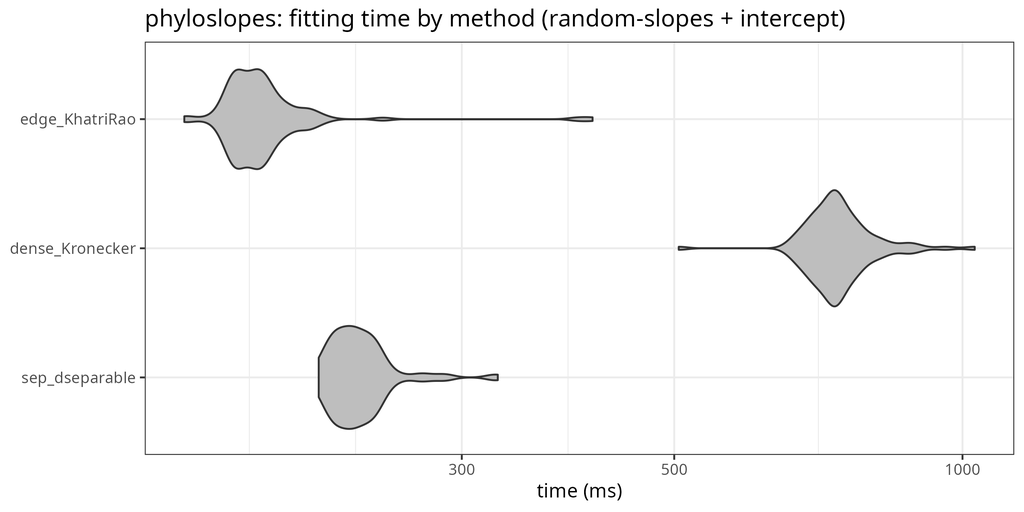

### thin-plate spline

Moving on to the case where we include not just a linear term, but a separate penalized term — following McGillycuddy *et al.* we’ll use a thin-plate spline (although the general concepts would extend to other smooth/penalized terms: other one-dimensional splines, Gaussian random fields, etc.). The tricky part here is that we have to handle the null components of the model separately. In the case of the separable model, we first use `mgcv()`’s `smooth2random()` utility to separate the spline term into null-space components (which are treated as fixed effects, i.e. unpenalized) and into a random-effects basis where the covariance structure is encoded in the model matrix (as in the `phyloglmm` case discussed above), so that $\boldsymbol \Sigma_{\textrm{wiggly}}$ becomes diagonal. The covariance matrix corresponding to the penalty is
$$\underbrace{\sigma_{\textrm{phylo}}^2 \boldsymbol \Sigma_{\textrm{phylo}}}_{\textrm{phylo intercept}} +
\underbrace{\sigma_{\textrm{wiggly}}^2 \boldsymbol \Sigma_{\textrm{wiggly}}}_{\textrm{non-phylogenetic wiggle}} + \underbrace{\sigma_{\textrm{phylo} \otimes \textrm{wiggly}}^2 \left(\boldsymbol \Sigma_{\textrm{phylo}} \otimes \boldsymbol \Sigma_{\textrm{wiggly}} \right)}_{\textrm{phylogenetic wiggle}}$$

Implemented as follows:

```r
nllfun_spline_separable <- function(params) {
  getAll(params, chdat_x)
  mu <- drop(Xfull %*% beta + Xr %*% b_spline + Xr_joint %*% b_wiggly + Zphylo %*% b_phylo)
  resid <- log_rs - mu
  Sigma_wiggly <- diag(Kw)
  Sigma_full <- kronecker(vcmat, Sigma_wiggly)
  pen_spline <- -sum(dnorm(b_spline, 0, sd = exp(logsd_f), log = TRUE))
  pen_phylo <- -dmvnorm(b_phylo, Sigma = vcmat, scale = exp(logpsd), log = TRUE)
  pen_wiggly <- -dmvnorm(b_wiggly, Sigma = Sigma_full, scale = exp(logpsd_f), log = TRUE)
  lik <- -sum(dnorm(log_rs, mean = mu, sd = exp(logsd), log = TRUE))
  lik + pen_spline + pen_wiggly + pen_phylo
}
```

The separable model reduces to the additive model if $\sigma_{\textrm{phylo} \otimes \textrm{wiggly}}\to 0$, i.e. `logpsd_f` $\to -\infty$.

For this problem we can also consider a tensor product smooth. As described in Wood (2017) section 5.6, the tensor product model matrix is built by combining the model matrices for each term via rowwise Kronecker products (see `mgcv::tensor.prod.model.matrix`); the tensor penalty is an additive combination of two separate penalty matrices, $\mathbf Q_{\textrm{phylo}} \otimes \mathbf I_{\textrm{wiggly}}$ and $\mathbf I_{\textrm{phylo}} \otimes \mathbf Q_{\textrm{wiggly}}$.[^2] As discussed above for the separable model, we also have to separate the components of $\mathbf Z$ that correspond to the nullspace of the penalty and treat them as (unpenalized) fixed effects. This is done manually below, not using the built-in `te()` machinery from `mgcv` … the penalty combines one term based on the tensor product precision,
$$\sigma_{T1}^{-2} \mathbf Q_{\textrm{phylo}} \otimes \mathbf I_{\textrm{wiggly}} + \sigma_{T2}^{-2}\mathbf I_{\textrm{phylo}} \otimes \mathbf Q_{\textrm{wiggly}}$$
and a null-space covariance matrix
$$\boldsymbol \Sigma_{\textrm{phylo}} \otimes \boldsymbol \Sigma_{\textrm{null}}$$
identical to the covariance matrix in the random-slopes linear model above. Implementation:

```r
nllfun_spline_tensor <- function(params) {
    getAll(params, chdat_x)
    mu <- drop(X %*% beta + Xnull_joint %*% c(t(b_null)) + Xrange_joint %*% b_range)
    resid <- log_rs - mu
    pen_null <- -dseparable(mk_f_phylo(vcmat, 1), mk_f_cov(us2, cor_null, logpsd_null))(b_null)
    Q_range <- exp(-2 * logsigma1_range) * Qr_phylo + exp(-2 * logsigma2_range) *
        Qr_smooth
    pen_range <- -dgmrf(b_range, Q = to_Q(Q_range), log = TRUE)
    lik <- -sum(dnorm(log_rs, mean = mu, sd = exp(logsd), log = TRUE))
    lik + pen_null + pen_range
}
```

This tensor-product construction is actually more flexible than `mgcv`’s default approach, which would set $\boldsymbol \Sigma_{\textrm{null}}$ to $\sigma_{T1}^2 \mathbf I_2$. It is (surprisingly) hard to get either this approach or `mgcv`’s to reduce to the additive model …

Tangentially, Wood (2017) is dismissive of the value of separable models; however, his example is extreme:

> For example, consider a smooth of 3 predictors constructed as a tensor product smooth of 3 cubic spline bases, each of rank 5. The resulting smooth would have 125 free parameters, but a penalty matrix of rank 27. This means that varying the weight given to the penalty would only result in the effective degrees of freedom for the smooth varying between 98 and 125: not a very useful range. By contrast, for the same marginal bases, the multiple term penalties would have rank 117, leading to a much more useful range of effective degrees of freedom of between 8 and 125.

### tiny example

[I’ve tried to come up with a simple way to get a more heuristic idea of what these models are doing, without too much success. It’s hard to construct a problem that’s small enough to visualize (i.e. few species, few knots in the spline) but large enough to fit without the models collapsing to singular or other non-identifiable cases]

Starting with a very small example that will (hopefully) allow visualizizing the penalty matrices/covariance matrices/etc. used by the different approaches. The example here uses a simple phylogeny with $S=5$ tips/species, with each species having a different $x$ value, and a thin-plate spline over $x$ with $K=4$.

| model | penalty/variance params | latent variables | latent variables |
| --- | --- | --- | --- |
| additive | 2 — `logsd_f` (iid wiggle scale), `logpsd` (phylo intercept scale) | 7 — `b_spline` (2) + `b_phylo` (5) | $(K-2) + S$ |
| separable | 3 — `logsd_f`, `logpsd_f` (phylo-correlated wiggle-deviation scale), `logpsd` | 17 — `b_spline` (2) + `b_wiggly` (10) + `b_phylo` (5) | $S(K-1) + (K-2)$ |
| tensor | 3 — `logpsd_null` (×2, one per null-space direction), `logpsd_range` | 20 — `b_null` (10) + `b_range` (10) | $SK$ |

For this tiny example, the separable model collapses back to the additive model.

```
          dLogLik dAIC df
additive      4.1    0  5
separable     4.1    2  6
tensor        0.0   12  7
```

Here are plots of the covariances between the predicted values of species 1-5 at $x=3$ and their slopes at $x=3$; ‘fitted’ refers to predictions for the fitted model (at the estimated parameters), ‘true’ shows predictions for the original parameters used for simulation.

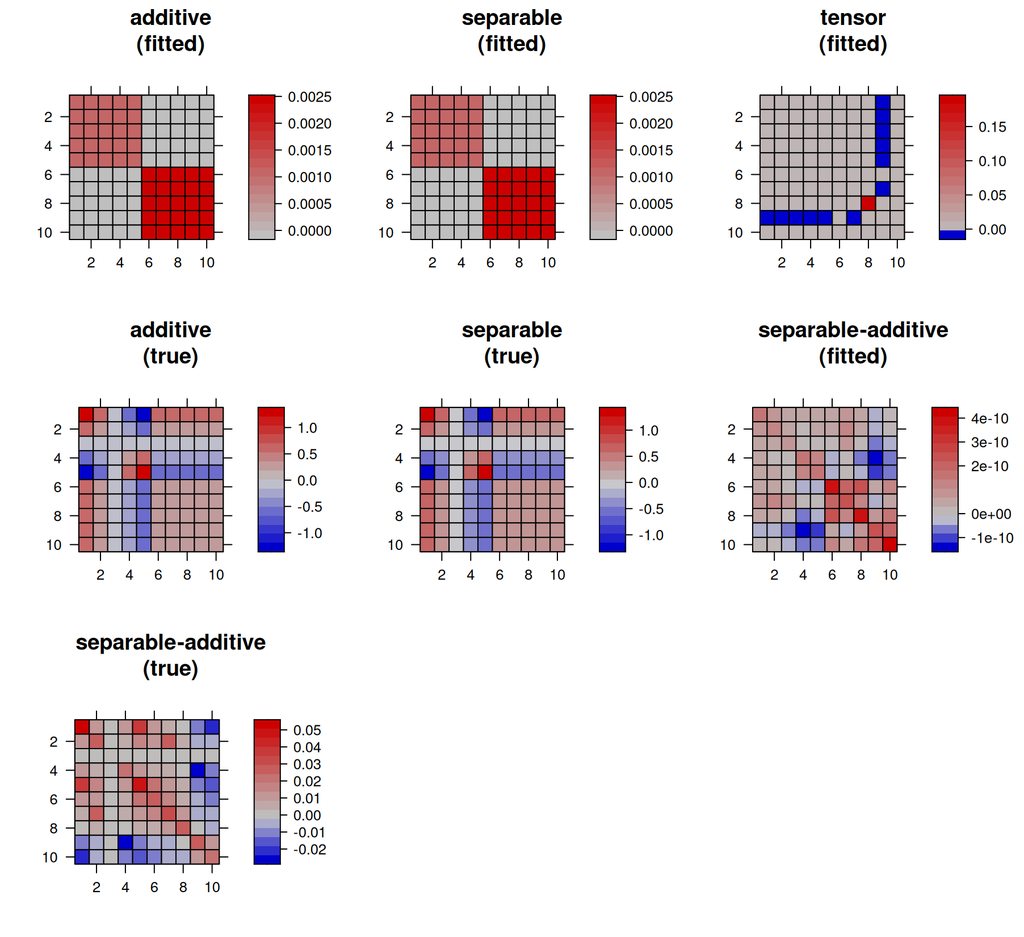

I still haven’t figured out a great way to illustrate the differences among these approaches.

### results of spline fits

The analogous comparison with a smooth (thin-plate spline) trend in `log_bm` instead of a linear one: null (phylogenetic intercept only), additive, separable, and a genuine tensor-product smooth (see `phyloslopes_combo.R`). `tensor` is the null/range-decomposed “hybrid” construction (`nllfun_spline_tensor`); `tensor (naive te())` is the same tensor-product smooth built directly from `mgcv::smooth.construct()`‘s raw, undecomposed `te()` basis (`nllfun_tensor`) – included here as a stand-in for `mgcv::gam()`’s own `te()` fit, since that doesn’t actually converge on this data (see `README_tensor.qmd`) and its `logLik()` wouldn’t be directly comparable to the RTMB fits’ here even if it did.

```r
load("phyloslopes_combo.rda")
tt <- bbmle::AICtab(phyloslopes_combo_models, logLik = TRUE)
print(as.data.frame(tt), digits = 2)
```

```
                    dLogLik dAIC df
null                   0.00  0.0  3
additive               0.54  2.9  5
tensor (naive te())    0.16  3.7  5
separable              0.54  4.9  6
tensor                 0.53  6.9  7
```

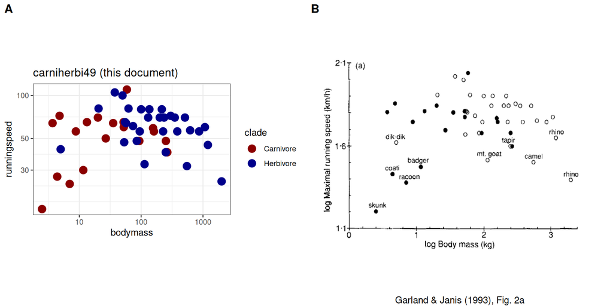

```r
p_ours <- ggplot(chdat, aes(bodymass, runningspeed, colour = clade)) +
  geom_point(size = 4) +
  scale_x_log10() +
  scale_y_log10() +
  scale_colour_manual(values = c("darkred", "darkblue")) +
  labs(title = "carniherbi49 (this document)") +
  theme(aspect.ratio = 1/1.5)  ## plot region ~1.5:1 (horizontal:vertical), matching Fig. 2a
p_orig <- cowplot::ggdraw() +
  cowplot::draw_image("garlandjones1993_fig2a.png") +
  cowplot::draw_label("Garland & Janis (1993), Fig. 2a", y = 0.02, size = 11)
cowplot::plot_grid(p_ours, p_orig, labels = c("A", "B"))
```

## References

Augustin, N.H. *et al.* (2013) “Space-time modelling of blue ling for fisheries stock management,” *Environmetrics*, 24(2), pp. 109–119. doi:10.1002/env.2196.

Bates, D. *et al.* (2015) “Fitting linear mixed-effects models using Lme4,” *Journal of Statistical Software*, 67, pp. 1–48. doi:10.18637/jss.v067.i01.

Clark, N. (2024) “Phylogenetic smoothing using mgcv,” *GAMbler*. Available at: https://ecogambler.netlify.app/blog/phylogenetic-smooths-mgcv/ (Accessed: August 13, 2026).

Garland, T. and Janis, C.M. (1993) “Does metatarsal/femur ratio predict maximal running speed in cursorial mammals?” *Journal of Zoology*, 229(1), pp. 133–151. doi:10.1111/j.1469-7998.1993.tb02626.x.

Hefley, T.J. *et al.* (2017) “The basis function approach for modeling autocorrelation in ecological data,” *Ecology*, 98(3), pp. 632–646. doi:10.1002/ecy.1674.

Hodges, J.S. and Clayton, M.K. (2011) “Random Effects Old and New.” Available at: http://www.biostat.umn.edu/~hodges/RPLMBook/Manuscripts/Hodges-ClaytonRandomEffectsOldAndNew.pdf.

Pedersen, E.J. *et al.* (2019) “Hierarchical generalized additive models in ecology: An introduction with mgcv,” *PeerJ*, 7, p. e6876. doi:10.7717/peerj.6876.

Rabosky, D.L. *et al.* (2018) “An inverse latitudinal gradient in speciation rate for marine fishes,” *Nature*, 559(7714), pp. 392–395. doi:10.1038/s41586-018-0273-1.

Säfken, B. *et al.* (2021) “Conditional Model Selection in Mixed-Effects Models with cAIC4,” *Journal of Statistical Software*, 99, pp. 1–30. doi:10.18637/jss.v099.i08.

Schielzeth, H. and Forstmeier, W. (2009) “Conclusions beyond support: Overconfident estimates in mixed models,” *Behavioral Ecology*, 20(2), pp. 416–420. doi:10.1093/beheco/arn145.

Wood, S.N. (2017) *Generalized additive models: An introduction with R*. 2nd ed. Chapman & Hall (CRC texts in statistical science).

## Footnotes

[^1]: the standard AIC is not necessarily appropriate for GAMs - it counts ‘top-level’ (fixed-effect + penalty) parameters, not the effective degrees of freedom, which is probably more meaningful: see e.g. Hodges and Clayton (2011), Säfken *et al.* (2021)
[^2]: The Claude-generated code I use here does *not* (I think) use the reparameterization suggested on pp. 230-231 of Wood (2017); I think that means that > the penalties no longer have the interpretation in terms of (averaged) function shape that is inherited from the marginal smooths … but I think (??) we still get the same overall fits.